# Indexação no R

## Introdução

A indexação no R é realizada com o operador `[` que aceita:

- `numeric` (que são convertidos para `integer`)
  - podem ser positivos ou negativos
- `logical`

O foco é na indexação de vetores, em 1 dimensão, mas as operações podem ser aplicadas a objetos com mais dimensões.

Nos exemplos vamos utilizar o vetor `quad` de quadrados perfeitos.

```r
(quad <- (1:9)^2)
```

```
## [1]  1  4  9 16 25 36 49 64 81
```

## Indexação simples

- A indexação com `numeric` é a indexação por posição
- O `numeric` passado ao operador `[` identifica a posição do vetor
- A posição do primeiro elemento de um vetor é 1, **não há elemento 0 em R**

```r
quad[1] # primeiro elemento do vetor
```

```
## [1] 1
```

```r
quad[2] # segundo elemento do vetor
```

```
## [1] 4
```

## Indexação múltipla

- Dado que os valores `numeric` indicam a posição dos elementos no vetor, passando diversas posições retorna diversos elementos

```r
quad[c(1,3,5,7,9)]
```

```
## [1]  1  9 25 49 81
```

```r
quad[3:7]
```

```
## [1]  9 16 25 36 49
```

## Indexação negativa

- O operador `[` aceita valores negativos
- Valores negativos invertem a seleção, ou seja, seleciona todos exceto os valores negativos
- O operador `[` aceita todos os valores negativos ou positivos
- Não é possível misturar valores positivos e negativos

```r
quad[-2]
```

```
## [1]  1  9 16 25 36 49 64 81
```

```r
quad[-c(1,3,5,7,9)]
```

```
## [1]  4 16 36 64
```

## Indexação com boleanos

- O operador `[` aceita valores `logical`
- `TRUE` seleciona os elementos e `FALSE` ignora

```r
(lt.25 <- quad < 25)
```

```
## [1]  TRUE  TRUE  TRUE  TRUE FALSE FALSE FALSE FALSE FALSE
```

```r
quad[lt.25]
```

```
## [1]  1  4  9 16
```

```r
(even <- quad %% 2 == 0)
```

```
## [1] FALSE  TRUE FALSE  TRUE FALSE  TRUE FALSE  TRUE FALSE
```

```r
quad[even]
```

```
## [1]  4 16 36 64
```

## Indexação com boleanos—Exemplo

```r
sd(v <- rnorm(1000))
```

```
## [1] 1.015061
```

```r
sd(vp <- v[(v > quantile(v, 0.05)) & (v < quantile(v, 0.95))])
```

```
## [1] 0.8139228
```

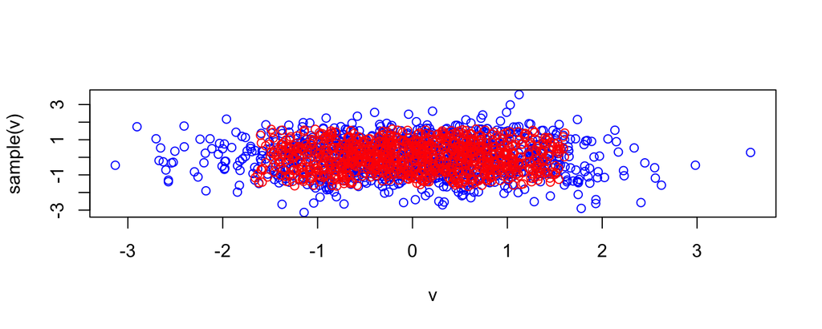

## Indexação com boleanos

- O comprimento do vetor `logical` passado para o operador `[` deve ter o mesmo comprimento do vetor (como no slide anterior)
  - se o comprimento for menor a regra de reciclagem será aplicada
  - se o comprimento for maior os elementos excedentes serão ignorados

## Regra de reciclagem

## Funções que ajudam na indexação

- match
- which
- which.min e which.max
- findInterval